# Data acquisition and processing: Genotyping (YOY & Adults)

Red Drum Broodstock offspring comparison

SJ O’Leary

2019-10-29

# Reference construction

Draft genome of red drum used as reference genome for read mapping.

# Read mapping

## Map reads using BWA

Map reads to reference genome as implmented in `dDocent` (Puritz, Hollenbeck, and Gold 2014) pipeline. Transfer copy of draft genome and rename to `reference.fasta` into each directory containing demultiplexed and quality trimmed sequences.

Puritz, Jonathan B, Christopher M Hollenbeck, and John R Gold. 2014. “dDocent : a RADseq, variant-calling pipeline designed for population genomics of non-model organisms.” *PeerJ* 2: e431. https://doi.org/10.7717/peerj.431.

Any renaming of files needs to happen before `fastq`-files are mapped. The population designation (before underscore) is used by `FreeBayes` to call SNPs so it is important that population designation make biological sense. All files should be named `SPECIES_PLATE-WELL_SAMPLENAME`.

## QA/QC read mapping

During the mapping stage, `dDocent` calls `BWA` to map reads from the individuals in the folder to the generated MiSeqReference and create a `-RG.bam`-file for each individual. The second column of a BAM (or SAM) file contains FLAGs with binary encoded information on mapping, pairedness etc. that can be used to compare the mapping efficiency.

Count number of reads and mapped reads using `samtools idxstats <aln-RG.bam>` (Li and Durbin 2009) which will retrieve and print stats in the bam-file. The output is TAB-delimited with each line consisting of reference sequence name, sequence length, # mapped reads and # unmapped (empty) reads. `samtools` can also be be used to query `samtools flagstat file.bam` which returns an output containing the number of reads for which each flag is true.

Li, Heng, and Richard Durbin. 2009. “Fast and accurate short read alignment with Burrows-Wheeler transform.” *Bioinformatics* 25 (14): 1754–60. https://doi.org/10.1093/bioinformatics/btp324.

dDocent writes out a file called `bamlist.list` that contains all the bam files that were generated during read mapping in `dDocent` using `BWA`. Write script to gather flagstats from all `bam`-files.

Run flagstats.

Write script to gather idxstats from all `bam`-files.

Run idxstats.

Appending the file results in the information per individual being printed in a new set of row being appended to the file, i.e. there will be as many rows for a given locus as individuals were mapped. The file can be re-formatted and summary statistics calculated using dplyr and tidyr.

Format idxstats.

Format flagstats.

Compare summary mapping statistics:

mean number of reads mapped per individual and mean proportion of reads not mapped as proper pair

[output not shown]

# SNP calling

Transfer copy reference genome (as `reference.fasta`) into SNP calling directory. Create symlinks from all `fq`, `bam` and `bam.bai`-files for each separately mapped library in `SNP_Calling` folder.

Execute `dDocent` from within `SNP_Calling`-folder to call variants across all individuals (all libraries) using `freebayes` (Garrison and Marth 2012).

Garrison, Erik, and Gabor Marth. 2012. “Haplotype-based variant detection from short-read sequencing.” *Plos One* 11 (3): e0151651. https://doi.org/arXiv:1207.3907 [q-bio.GN].

```
cd /home/soleary/DRUM/data/SNP_Calling
dDocent
```

File `TotalrawSNPs.vcf` contains all raw SNP/INDEL calls. Copy `TotalRaSNPs.vcf` to `VCF_Filtering` for SNP filtering.

```
cd /home/soleary/DRUM/data/SNP_Calling
rm *fq.gz *bam*

cp /home/soleary/DRUM/data/SNP_Calling/TotalRawSNPs.vcf /home/soleary/DRUM/data/VCF/temp/

vcftools --vcf data/VCF/temp/TotalRawSNPs.vcf --out data/VCF/SOC_raw --depth
vcftools --vcf data/VCF/temp/TotalRawSNPs.vcf --out data/VCF/SOC_raw --site-mean-depth
vcftools --vcf data/VCF/temp/TotalRawSNPs.vcf --out data/VCF/SOC_raw --missing-indv
vcftools --vcf data/VCF/temp/TotalRawSNPs.vcf --out data/VCF/SOC_raw --missing-site

vcfsamplenames data/VCF/temp/TotalRawSNPs.vcf > data/VCF/raw.ind
```

# SNP filtering

O’Leary, Shannon J, Jonathan B Puritz, Stuart C Willis, Christopher M Hollenbeck, and David S Portnoy. 2018. “These aren’t the loci you’re looking for: Principles of effective SNP filtering for molecular ecologists.” Wiley/Blackwell (10.1111). https://doi.org/10.1111/mec.14792.

Missing data and mean depth for unfiltered SNP data set

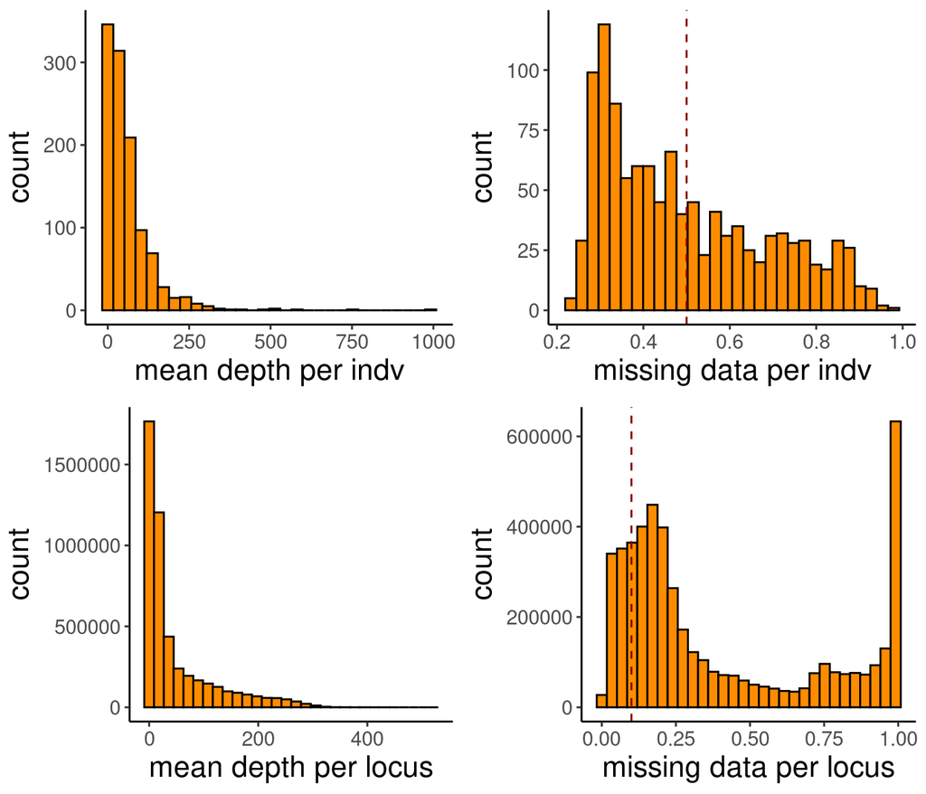

Data set contains 4850886 loci. Individuals with mean depth < 3 and > 80% missing data flagged as low quality individuals.

## Filter 0: Decompose indels

Decompose complex variants.

```
# decompose indels
vcfallelicprimitives data/VCF/temp/TotalRawSNPs.vcf --keep-info --keep-geno > data/VCF/temp/SOC.prim.vcf
```

## Filter 1: Remove low quality loci and individuals

```
vcftools --vcf data/VCF/temp/SOC.prim.vcf --out data/VCF/temp/SOC.F1a --remove-indels --remove data/VCF/LQ_raw.ind --recode --recode-INFO-all

vcftools --vcf data/VCF/temp/SOC.F1a.recode.vcf --out data/VCF/temp/SOC.F1 --minQ 20 --mac 3 --min-alleles 2 --max-alleles 2 --max-missing 0.5 --min-meanDP 15 --recode --recode-INFO-all

vcftools --vcf data/VCF/temp/SOC.F1.recode.vcf --out data/VCF/SOC.F1 --depth
vcftools --vcf data/VCF/temp/SOC.F1.recode.vcf --out data/VCF/SOC.F1 --site-mean-depth
vcftools --vcf data/VCF/temp/SOC.F1.recode.vcf --out data/VCF/SOC.F1 --missing-indv
vcftools --vcf data/VCF/temp/SOC.F1.recode.vcf --out data/VCF/SOC.F1 --missing-site
vcftools --vcf data/VCF/temp/SOC.F1.recode.vcf --out data/VCF/SOC.F1 --geno-depth

vcfsamplenames data/VCF/temp/SOC.F1.recode.vcf > data/VCF/F1.ind
```

Patterns of missing data and mean depth after removing low quality loci and individuals

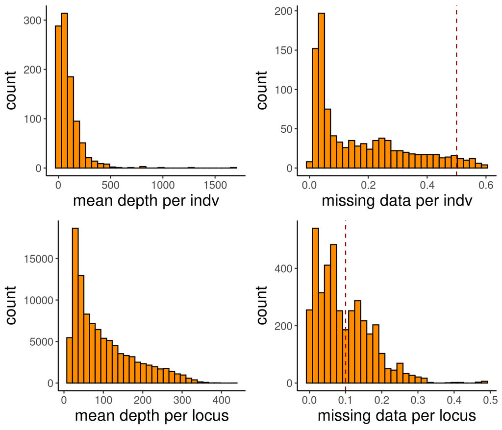

Proportion of genotypes within each depth bin

| GDEPTHBIN | n | PERCENT |
| --- | --- | --- |
| <5 | 17382936 | 0.17 |
| 5-10 | 9898076 | 0.10 |
| 10-25 | 15418540 | 0.15 |
| 25-50 | 11164548 | 0.11 |
| 50-100 | 9506382 | 0.09 |
| 100-500 | 16280825 | 0.16 |
| >500 | 3823234 | 0.04 |
| NA | 17178664 | 0.17 |

## Filter 2: Filter low quality genotypes.

```
vcftools --vcf data/VCF/temp/SOC.F1.recode.vcf --out data/VCF/temp/SOC.F2a --minGQ 30 --minDP 10 --recode --recode-INFO-all
vcftools --vcf data/VCF/temp/SOC.F2a.recode.vcf --out data/VCF/temp/SOC.F2 --max-missing 0.5 --recode --recode-INFO-all

vcftools --vcf data/VCF/temp/SOC.F2.recode.vcf --out data/VCF/SOC.F2 --depth
vcftools --vcf data/VCF/temp/SOC.F2.recode.vcf --out data/VCF/SOC.F2 --site-mean-depth
vcftools --vcf data/VCF/temp/SOC.F2.recode.vcf --out data/VCF/SOC.F2 --missing-indv
vcftools --vcf data/VCF/temp/SOC.F2.recode.vcf --out data/VCF/SOC.F2 --missing-site

vcfsamplenames data/VCF/temp/SOC.F2.recode.vcf > data/VCF/F2.ind
```

Genotypes with < 10 reads or genotype quality < 30 are coded as missing, loci with large number of low quality genotypes will have increased proportion of missing data. Remove low with genotype call rate < 50%.

Patterns of missing data and mean depth after removing low quality genotypes and adjusting for missing data

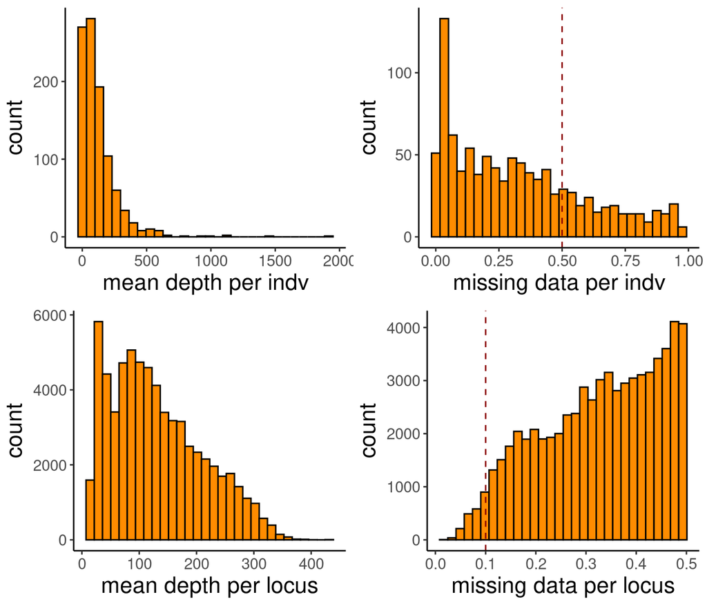

Data set contains 995 individuals genotyped for 65346 loci.

## Filter 3: Allele balance

```
cd data/VCF/temp

cut -f8 SOC.F2.recode.vcf | grep -oe "AB=[[:digit:]].[[:digit:]][[:digit:]][[:digit:]]" | sed -s 's/AB=//g' > SOC.F3.AB

vcffilter -s -f "AB > 0.2 & AB < 0.8 | AB < 0.01 | AB > 0.99" -s -g "QR > 0 | QA > 0" SOC.F2.recode.vcf > SOC.F3.vcf

mawk '!/#/' SOC.F3.vcf | wc -l
```

Allele balance is the ratio of reads for reference allele to all reads, considering only reads from individuals called as heterozygous at that locus. Values range from 0 - 1. Filter SNP calls with AB > 0.2, AB > 0.8; retain loci very close to 0 to retain loci that are fixed variants. Remove genotypes if the quality sum of the reference or alternate allele is 0.

Allele balance

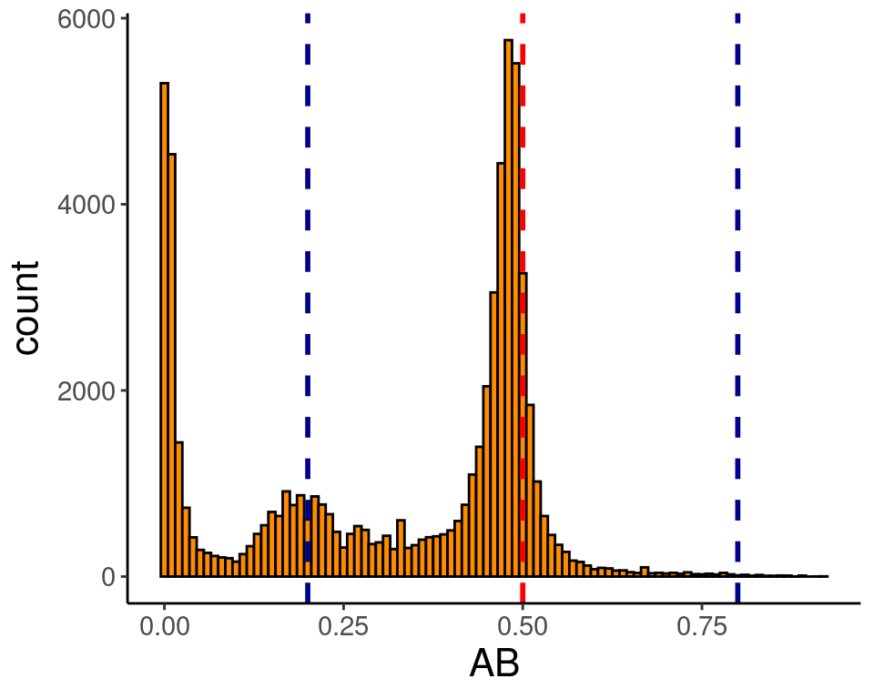

Remaining SNPs: 53,274.

## Filter 4: Quality/depth ratio

```
# site depth
cut -f8 SOC.F3.vcf | grep -oe "DP=[0-9]*" | sed -s 's/DP=//g' > SOC.3.DEPTH

# quality score
mawk '!/#/'  SOC.F3.vcf | cut -f1,2,6 > SOC.F3.loci.qual

vcffilter -s -f "QUAL / DP > 0.2" SOC.F3.vcf > SOC.F4.vcf

mawk '!/#/' SOC.F4.vcf | wc -l
```

SNP quality should increase with depth. Remove loci with quality/depth ratio < 0.2.

Distribution of quality/depth ratio

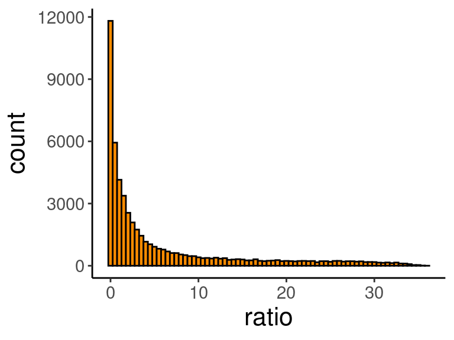

Remaining SNPs: 42,117.

## Filter 5: mapping quality

```
cut -f8 SOC.F4.vcf | grep -oe "MQM=[0-9]*" | sed -s 's/MQM=//g' > SOC.F4.MQM

cut -f8 SOC.F4.vcf | grep -oe "MQMR=[0-9]*" | sed -s 's/MQMR=//g' > SOC.F4.MQMR

vcffilter -s -f "MQM / MQMR > 0.25 & MQM / MQMR < 1.75" SOC.F4.vcf > SOC.F5.vcf

mawk '!/#/' SOC.F5.vcf | wc -l
```

Remove loci based on ratio of mapping quality for reference and alternate allele, i.e. sites that have a high discrepancy between the mapping qualities of two alleles. Filter loci with mapping quality ratio < 0.25 and > 1.75.

Relationship of mapping quality for reference and alternate allele

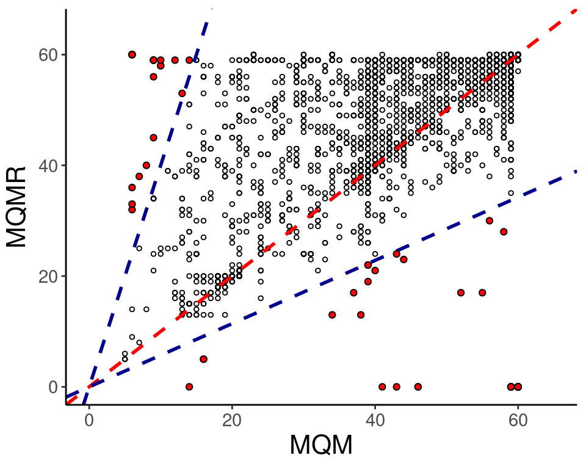

Remaining SNPs: 42,053

## Filter 6: Strand balance

```
cut -f8 SOC.F5.vcf | grep -oe "SAF=[0-9]*" | sed -s 's/SAF=//g' > SOC.F5.SAF

cut -f8 SOC.F5.vcf | grep -oe "SAR=[0-9]*" | sed -s 's/SAR=//g' > SOC.F5.SAR

cut -f8 SOC.F5.vcf | grep -oe "SRF=[0-9]*" | sed -s 's/SRF=//g' > SOC.F5.SRF

cut -f8 SOC.F5.vcf | grep -oe "SRR=[0-9]*" | sed -s 's/SRR=//g' > SOC.F5.SRR

vcffilter -f "SAF / SAR > 100 & SRF / SRR > 100 | SAR / SAF > 100 & SRR / SRF > 100" -s SOC.F5.vcf > SOC.F6.vcf

mawk '!/#/' SOC.F6.vcf | wc -l
```

Paired end reads should not overlap, and a SNP site should only be covered by either the forward or reverse read (strand). Remove SNP sites that have > 100x more forward alternate reads than reverse alternate reads and > 100x more forward reverse reads than reverse alternate reads.

Comparison of number of forward vs reverse reads covering a SNP locus

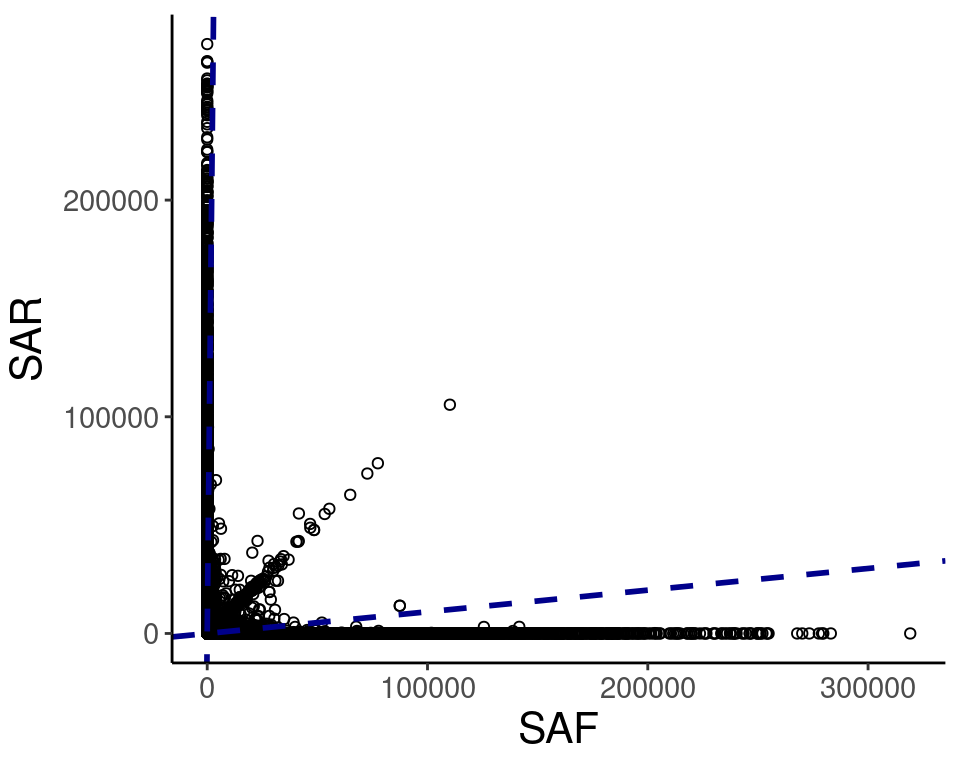

Number of SNPs remaining: 36,075.

## Filter 7: Properly paired status

Identify loci with only unpaired reads mapping to them. Compare number of paired reads mapping the reference and the alternate alleles to identify discrepancy in the paired status for reads supporting reference and alternate alleles.

```
vcffilter -f "PAIRED > 0.05 & PAIREDR > 0.05 & PAIREDR / PAIRED < 1.75 & PAIREDR / PAIRED > 0.25 | PAIRED < 0.05 & PAIREDR < 0.05" -s SOC.F6.vcf > SOC.F7.vcf

mawk '!/#/' SOC.F7.vcf | wc -l
```

Number of SNPs in data set: 35,986.

## Filter 8: Maximum depth & Quality

```
# site depth
cut -f8 SOC.F7.vcf | grep -oe "DP=[0-9]*" | sed -s 's/DP=//g' > SOC.F7.DEPTH

# quality score
mawk '!/#/'  SOC.F7.vcf | cut -f1,2,6 > SOC.F7.loci.qual
```

Site quality should increase with depth.

Relationship of site quality and mean depth

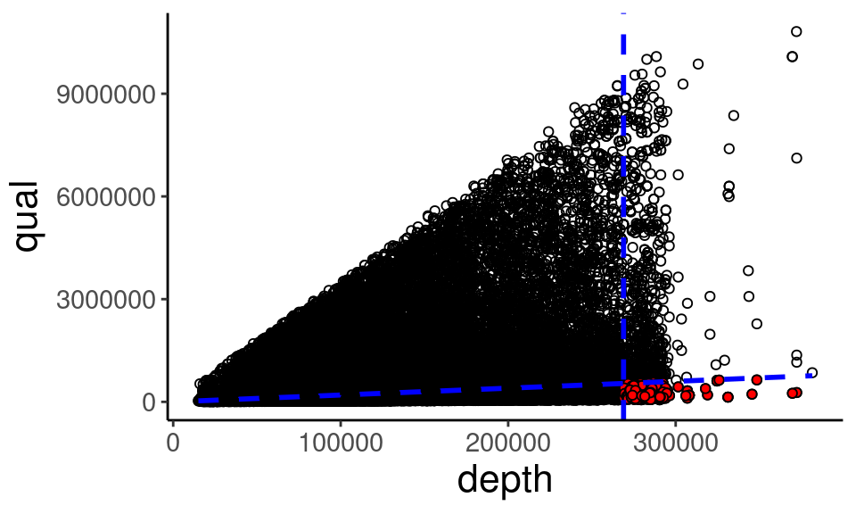

Filter SNP site with depth > mean depth + 1 standard deviation = 268884.1515732 and that have quality scores < 2x the depth at that site.

```
cd ../../../

vcftools --vcf  data/VCF/temp/SOC.F7.vcf --out data/VCF/temp/SOC.F8 --exclude-positions data/VCF/temp/LQ_F8.loci --recode --recode-INFO-all

vcftools --vcf data/VCF/temp/SOC.F8.recode.vcf --out data/VCF/SOC.F8 --depth
vcftools --vcf data/VCF/temp/SOC.F8.recode.vcf --out data/VCF/SOC.F8 --site-mean-depth
vcftools --vcf data/VCF/temp/SOC.F8.recode.vcf --out data/VCF/SOC.F8 --missing-indv
vcftools --vcf data/VCF/temp/SOC.F8.recode.vcf --out data/VCF/SOC.F8 --missing-site
```

Patterns of missing data and mean depth after removing loci based on allele balance, mapping quality, strandedness, and quality/depth relationship

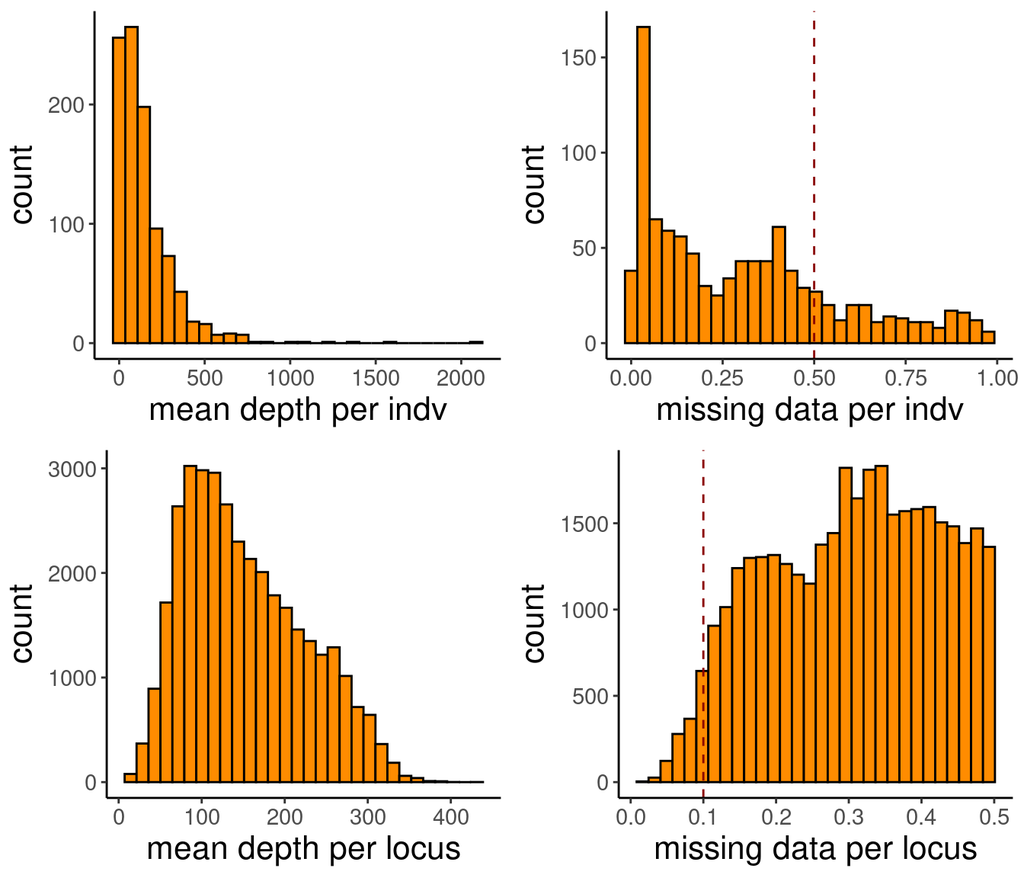

number of loci with > 10% missing data

| F_MISS > 0.1 | n |
| --- | --- |
| FALSE | 1136 |
| TRUE | 34429 |

Data set contains 995 individuals genotyped for 35565 loci.

## Filter 9: Genotype call rate and mean depth

```
vcftools --vcf data/VCF/temp/SOC.F8.recode.vcf --out data/VCF/temp/SOC.F9 --max-missing 0.9 --min-meanDP 20 --recode --recode-INFO-all

vcftools --vcf data/VCF/temp/SOC.F9.recode.vcf --out data/VCF/SOC.F9 --depth
vcftools --vcf data/VCF/temp/SOC.F9.recode.vcf --out data/VCF/SOC.F9 --site-mean-depth
vcftools --vcf data/VCF/temp/SOC.F9.recode.vcf --out data/VCF/SOC.F9 --missing-indv
vcftools --vcf data/VCF/temp/SOC.F9.recode.vcf --out data/VCF/SOC.F9 --missing-site
vcftools --vcf data/VCF/temp/SOC.F9.recode.vcf --out data/VCF/SOC.F9 --het
vcftools --vcf data/VCF/temp/SOC.F9.recode.vcf --out data/VCF/SOC.F9 --hardy
vcftools --vcf data/VCF/temp/SOC.F9.recode.vcf --out data/VCF/SOC.F9 --freq2
```

Filter loci with a genotype call rate < 90%.

Distribution of missing data and mean depth per locus and individual

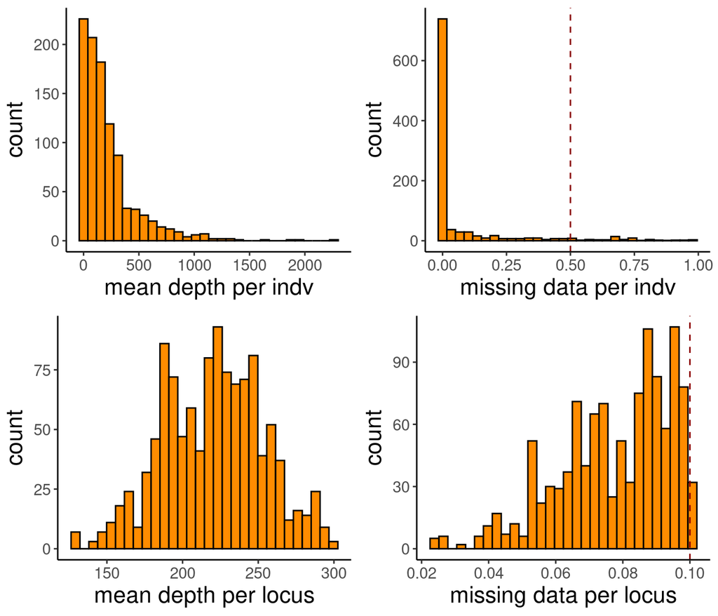

Data set contains 995 genotyped for 1136 loci.

## Filter 10: Excess heterozygosity

Levels of heterozygosity per locus and individual

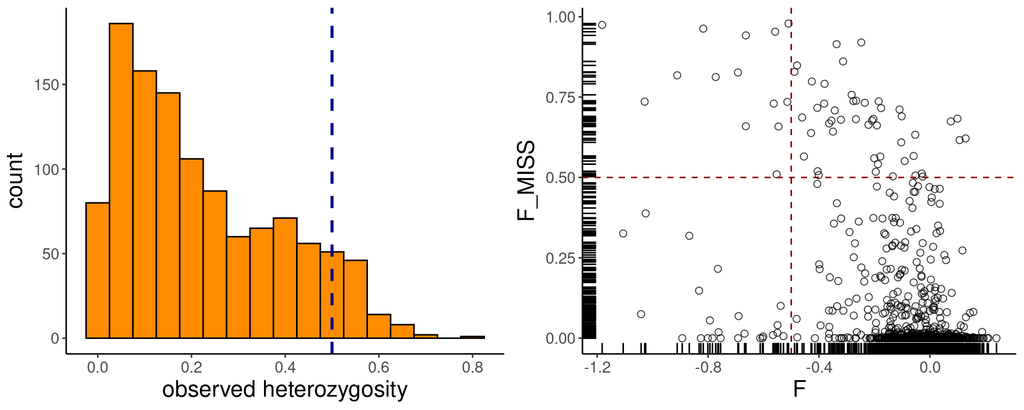

Identify loci with heterozygosity > 0.5, then correct p-values for multiple comparisons using Benjamini-Hochberg method. Flag individuals with > 50% missing data or excess heterozygosity (Fis < -0.5).

minor allele frequency

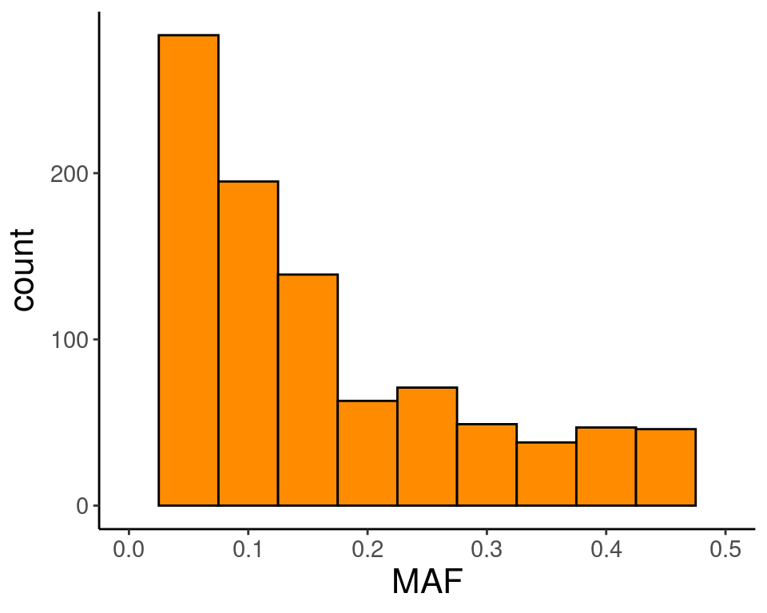

```
vcftools --vcf data/VCF/temp/SOC.F9.recode.vcf --out data/VCF/temp/SOC.F10 --exclude-positions data/VCF/hetexcess.loci --remove data/VCF/LQ_F10.ind --max-meanDP 310 --min-meanDP 20 --max-missing 0.9 --maf 0.01 --minDP 3 --min-alleles 2 --max-alleles 2 --minQ 20 --minGQ 20 --recode --recode-INFO-all

vcftools --vcf data/VCF/temp/SOC.F10.recode.vcf --out data/VCF/SOC.F10 --depth
vcftools --vcf data/VCF/temp/SOC.F10.recode.vcf --out data/VCF/SOC.F10 --site-mean-depth
vcftools --vcf data/VCF/temp/SOC.F10.recode.vcf --out data/VCF/SOC.F10 --missing-indv
vcftools --vcf data/VCF/temp/SOC.F10.recode.vcf --out data/VCF/SOC.F10 --missing-site
vcftools --vcf data/VCF/temp/SOC.F10.recode.vcf --out data/VCF/SOC.F10 --het
vcftools --vcf data/VCF/temp/SOC.F10.recode.vcf --out data/VCF/SOC.F10 --012
```

## Filter 11: Asess genotyping error

Compare duplicate individuals

Compare number of discordant genotype calls per duplicate set.

Propotion of discordant genotypes per individual and locus

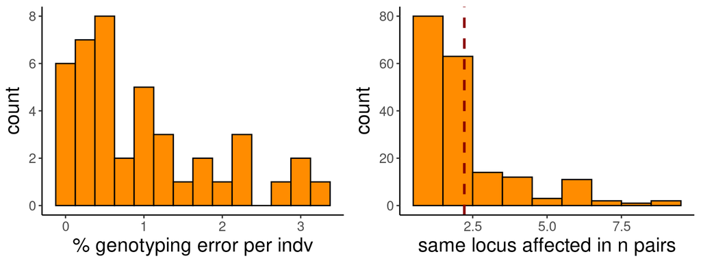

Identify loci consistently affected by genotyping error.

number of loci with discordant genotypes in > 3 pairs

| n > 3 | n |
| --- | --- |
| FALSE | 157 |
| TRUE | 31 |

Identify duplicate individuals to remove from data set.

```
vcftools --vcf data/VCF/temp/SOC.F10.recode.vcf --out data/VCF/temp/SOC.F11 --exclude-positions data/VCF/LQ_F11.loci --remove data/VCF/LQ_adults.ind --max-missing 0.9 --minDP 10 --min-alleles 2 --max-alleles 2 --minQ 20 --minGQ 30 --recode --recode-INFO-all

vcftools --vcf data/VCF/temp/SOC.F11.recode.vcf --out data/VCF/SOC.F11 --depth
vcftools --vcf data/VCF/temp/SOC.F11.recode.vcf --out data/VCF/SOC.F11 --site-mean-depth
vcftools --vcf data/VCF/temp/SOC.F11.recode.vcf --out data/VCF/SOC.F11 --missing-indv
vcftools --vcf data/VCF/temp/SOC.F11.recode.vcf --out data/VCF/SOC.F11 --missing-site
vcftools --vcf data/VCF/temp/SOC.F11.recode.vcf --out data/VCF/SOC.F11 --het
vcftools --vcf data/VCF/temp/SOC.F11.recode.vcf --out data/VCF/SOC.F11 --geno-r2
```

Remove loci identified as discordant genotypes in more than 3 duplicate pairs and retain one genotype per duplicate.

Distribution of missing data and mean depth for final data set

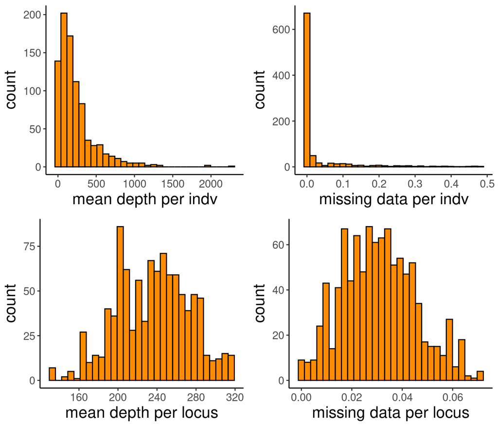

Assess genotyping error using `whoa`.

expected vs observed genotype frequencies for heterozygotes (1) and homozyogotes (0, 2)

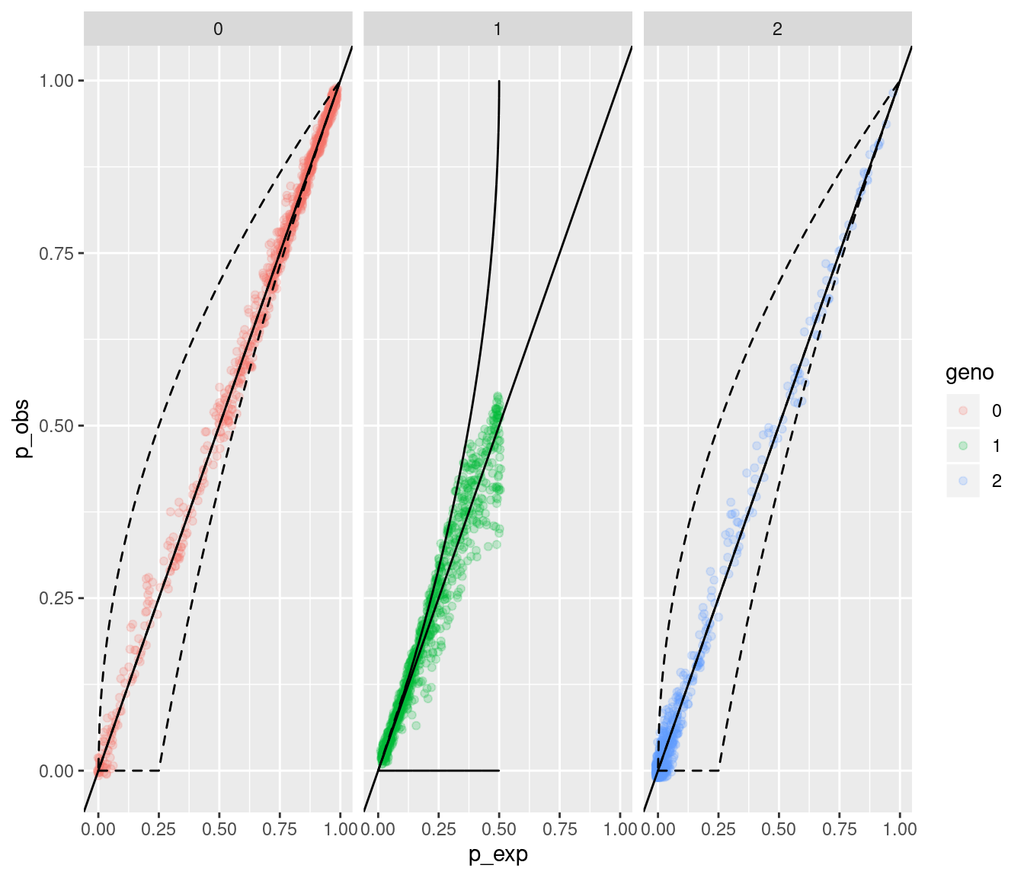

Estimate the heterozygosity miscall rate over all read depth bins.

mean genotyping error overall read depths

[output not shown]

mean genotyping error rate per read depth, red dashed line indicated mean genotyping error of 0.5%

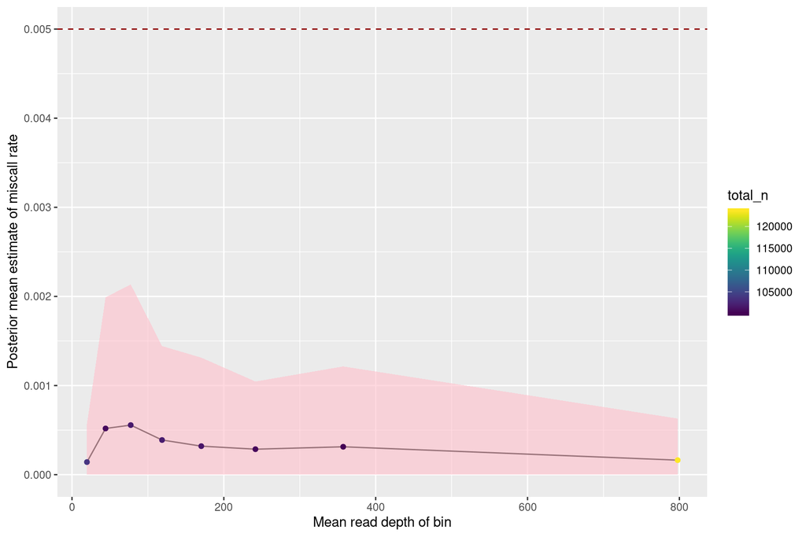

mean genotyping error per depth bin

| bin | mean | lo95 | hi95 | total_n | mean_dp |
| --- | --- | --- | --- | --- | --- |
| 1 | 0.0001412 | 0.0000006 | 0.0005666 | 103665 | 19.69643 |
| 2 | 0.0005182 | 0.0000016 | 0.0019894 | 100590 | 44.22008 |
| 3 | 0.0005563 | 0.0000022 | 0.0021350 | 101661 | 77.34836 |
| 4 | 0.0003888 | 0.0000015 | 0.0014430 | 101897 | 118.62117 |
| 5 | 0.0003199 | 0.0000014 | 0.0013131 | 101388 | 170.27441 |
| 6 | 0.0002858 | 0.0000009 | 0.0010453 | 100547 | 241.60412 |
| 7 | 0.0003129 | 0.0000013 | 0.0012144 | 100133 | 357.21779 |
| 8 | 0.0001627 | 0.0000007 | 0.0006295 | 123564 | 797.76312 |

## Filter 12: Linkage disequilibrium

Linkage disequilibrium assess as the squared correlation coefficient between genotypes encoded as 0, 1, and 2 (number of non-reference alleles in each individual).

linkage disequilibrium

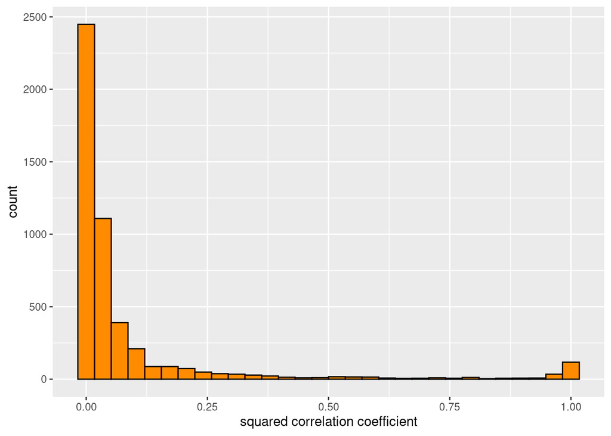

no of pairs with R2 > 0.5

| `R^2` > 0.5 | n |
| --- | --- |
| FALSE | 4609 |
| TRUE | 268 |

Remove one SNP from each pair with r2 > 0.5.

```
vcftools --vcf data/VCF/temp/SOC.F11.recode.vcf --out data/VCF/temp/SOCminDP10.genotyped --exclude-positions data/VCF/LQ_F12.loci --recode --recode-INFO-all

vcftools --vcf data/VCF/temp/SOCminDP10.genotyped.recode.vcf --out data/VCF/SOC.F12 --depth
vcftools --vcf data/VCF/temp/SOCminDP10.genotyped.recode.vcf --out data/VCF/SOC.F12 --site-mean-depth
vcftools --vcf data/VCF/temp/SOCminDP10.genotyped.recode.vcf --out data/VCF/SOC.F12 --missing-indv
vcftools --vcf data/VCF/temp/SOCminDP10.genotyped.recode.vcf --out data/VCF/SOC.F12 --missing-site
vcftools --vcf data/VCF/temp/SOCminDP10.genotyped.recode.vcf --out data/VCF/SOC.F12 --het
vcftools --vcf data/VCF/temp/SOCminDP10.genotyped.recode.vcf --out data/VCF/SOC.F12 --012

vcfsamplenames data/VCF/temp/SOCminDP10.genotyped.recode.vcf > data/VCF/SOCminDP10.genotyped.ind

cp ./data/VCF/temp/SOCminDP10.genotyped.recode.vcf ./data/ASSIGNMENT/
cp ./data/VCF/SOCminDP10.genotyped.ind ./data/ASSIGNMENT/

cp ./data/VCF/SOC.F12.012 ./data/ASSIGNMENT/SOCminDP10.F12.012
cp ./data/VCF/SOC.F12.012.pos ./data/ASSIGNMENT/SOCminDP10.F12.012.pos
cp ./data/VCF/SOC.F12.012.indv ./data/ASSIGNMENT/SOCminDP10.F12.012.indv
```

# Final data set

YOY were sample in three different rearing ponds in 2017 (n = 1) and 2018 (n = 2).

Number of adults and offspring sampled in three rearing ponds.

| GRP | n |
| --- | --- |
| ADULT | 24 |
| YOY-1 | 324 |
| YOY-2 | 280 |
| YOY-3 | 246 |

For each pond offspring were sampled at three time points, after stocking ponds (T1), mid-way (T2) and as YOY were removed to be stocked in the bay. Target sample size was approximately 100 YOY, due to cold temperatures growth was slow for some ponds making it difficult to obtain the targeted sample size.

Number offspring sampled at each time point.

| GRP | T1 | T2 | T3 |
| --- | --- | --- | --- |
| YOY-1 | 111 | 87 | 126 |
| YOY-2 | 120 | 39 | 121 |
| YOY-3 | 56 | 108 | 82 |